# Speech Biomarkers of Parkinson’s Disease

Yuri Rykov

April 11, 2021

# Exploratory data analysis and predictive modelling

### Contents

1. Reading data and checking dimensionality
1. Exploratory analysis  
   1.1. Univariate analysis (Descriptive statistics)  
   1.1.1. Demographics  
   1.1.2. Health history, medications and clinical exam (symptoms)  
   1.1.3. Speech features  
   1.2. Bivariate and multivariave analysis  
   1.2.1. Correlation matrix of speech features  
   1.2.2. Scatterplots of speech features  
   1.2.3. PCA of speech features  
   1.2.4. Cluster analysis of participants using speech features
2. Predictive modelling: ‘early’ detection of neurodegeneration  
   2.1. PD patients -vs- healthy controls  
   2.2. PD and RBD patients -vs- healthy controls  
   2.3. Multiclass prediction with 3 classes (PD, RBD and healthy controls)  
   2.4. Neurodegeneration symptoms’ severity prediction (numeric prediction)
3. Finding patterns of neurodegeneration symptoms and predicting them by speech features  
   3.1. Finding symptom patterns with k-means cluster analysis  
   3.2. Predicting cluster of symptoms with speech features

### Read data and checking

```r
setwd("C:/R_neuro")
df = read.csv("dataset.csv")
dim(df) # dimensions of dataframe (sample size and variables)
```

```
## [1] 130  65
```

```r
lapply(df, class) # checking types of the data
```

```
## $Participant..code
## [1] "factor"
##
## $Age...years.
## [1] "integer"
##
## $Gender
## [1] "factor"
##
## $Positive..history..of..Parkinson..disease..in..family
## [1] "factor"
##
## $Age..of..disease..onset...years.
## [1] "factor"
##
## $Duration..of..disease..from..first..symptoms...years.
## [1] "factor"
##
## $Antidepressant..therapy
## [1] "factor"
##
## $Antiparkinsonian..medication
## [1] "factor"
##
## $Antipsychotic..medication
## [1] "factor"
##
## $Benzodiazepine..medication
## [1] "factor"
##
## $Levodopa..equivalent...mg.day.
## [1] "integer"
##
## $Clonazepam...mg.day.
## [1] "numeric"
##
## $Overview..of..motor..examination...Hoehn.....Yahr..scale.....
## [1] "factor"
##
## $Overview..of..motor..examination...UPDRS..III..total.....
```

[output cut: 139 more lines]

```
##
## $Decay..of..unvoiced..fricatives...â...min..1
## [1] "numeric"
##
## $Relative..loudness..of..respiration...dB..1
## [1] "numeric"
##
## $Pause..intervals..per..respiration......1
## [1] "numeric"
##
## $Rate..of..speech..respiration.....min..1
## [1] "numeric"
##
## $Latency..of..respiratory..exchange...ms..1
## [1] "integer"
```

```r
names(df)[42:65] = paste0("SF", seq(1,24)) # rename speech fetures with shorter names
```

Dataset is relatively small, it contains 130 cases (participants) and 65 variables.

### Group variables

```r
pred.dem = names(df[2:3]) # age and gender
pred.hist = names(df[4:6]) # health history
pred.meds = names(df[7:12]) # medications
mot.exam = names(df[13:14]) # clinical motor examination scores
symptoms = names(df[15:41]) # UPDRS III motor scale items (symptoms)
pred.voice = names(df[42:65]) # only 24 speech features (12 features x 2 speech tests)

df$label = substring(df$Participant..code, 1,2) #define labels - diagnostic category
```

## 1. Exploratory analysis

### 1.1. Univariate analysis (Descriptive statistics)

#### 1.1.1. Demographics

```r
library(psych)
library(Hmisc)
library(ggplot2)
df$a = "i" #create pseudo group
describe(df$Gender)
```

```
## df$Gender
##        n  missing distinct
##      130        0        2
##
## Value          F     M
## Frequency     27   103
## Proportion 0.208 0.792
```

Gender piechart

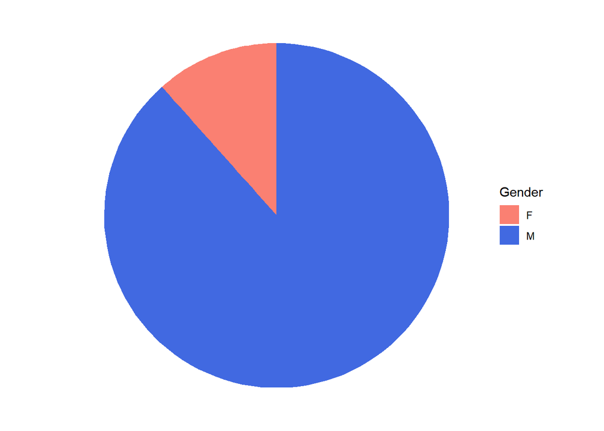

```r
ggplot(df, aes(x="", y=Gender, fill=Gender)) + geom_bar(width = 1, stat = "identity") + coord_polar("y", start=0) +
  theme_void() + xlab("") + scale_fill_manual(values=c("salmon", "royalblue"))
```

```r
describeBy(df$Age...years., group = df$a, mat=T, digits=3)[-c(1:4,8,9,15)]
```

```
##       mean     sd median min max range   skew kurtosis
## X11 64.331 10.134   66.5  34  83    49 -0.779    0.091
```

Age histogram

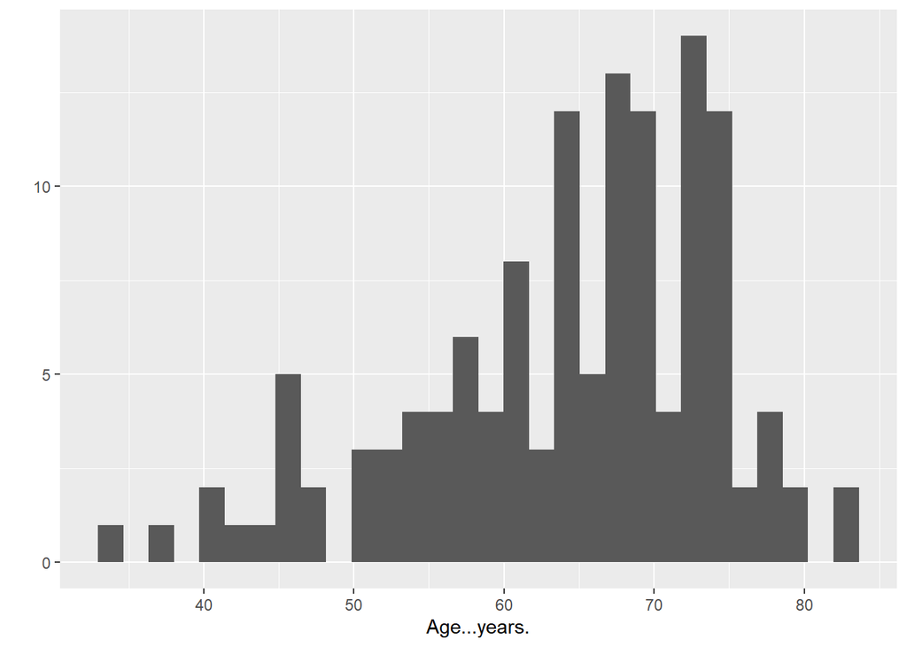

```r
qplot(Age...years., data = df, geom = "histogram")
```

Age-gender density plot

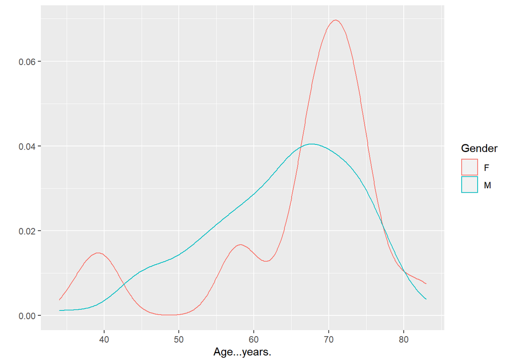

```r
qplot(Age...years., data = df, geom = "density", color = Gender)
```

#### 1.1.2. Health history, medications and clinical exam (symptoms)

```r
table(df$Positive..history..of..Parkinson..disease..in..family) #check values of one variable
```

```
##
##   -  No Yes
##  50  77   3
```

This value “-” means missing, should be replaced with proper missings (NAs).

```r
df[df == "-"] <- NA #replace "-" with NAs throughtout the dataset
ds2 = describe(df[,c(pred.hist, pred.meds, mot.exam, symptoms)])
ds2 # print descriptions of variables
```

```
## df[, c(pred.hist, pred.meds, mot.exam, symptoms)]
##
##  38  Variables      130  Observations
## ---------------------------------------------------------------------------
## Positive..history..of..Parkinson..disease..in..family
##        n  missing distinct
##       80       50        2
##
## Value         No   Yes
## Frequency     77     3
## Proportion 0.962 0.038
## ---------------------------------------------------------------------------
## Age..of..disease..onset...years.
##        n  missing distinct
##       80       50       34
##
## lowest : 30 32 33 36 37, highest: 73 74 76 78 81
## ---------------------------------------------------------------------------
## Duration..of..disease..from..first..symptoms...years.
##        n  missing distinct
##       80       50       19
##
## lowest : 0.5 0.7 1   10  11 , highest: 5   6   7   8   9
##
## Value        0.5   0.7   1.0  10.0  11.0  12.0  15.0  16.0  17.0   2.0
## Frequency      1     1    24     3     3     1     1     2     1    12
## Proportion 0.012 0.012 0.300 0.038 0.038 0.012 0.012 0.025 0.012 0.150
##
## Value        2.3   2.5   3.0   4.0   5.0   6.0   7.0   8.0   9.0
## Frequency      1     1     8     4     9     2     2     3     1
## Proportion 0.012 0.012 0.100 0.050 0.112 0.025 0.025 0.038 0.012
## ---------------------------------------------------------------------------
## Antidepressant..therapy
##        n  missing distinct
##      130        0       10
##
## lowest :  Yes  (Anafranil)   Yes  (Asentra)     Yes  (Aurorix)     Yes  (Cipralex)    Yes  (Citalec)
## highest:  Yes  (Remood)      Yes  (Trittico)    Yes  (Velaxin)     Yes  (Zoloft)     No
##
## Yes (Anafranil) (1, 0.008), Yes (Asentra) (1, 0.008), Yes (Aurorix) (1,
```

[output cut: 269 more lines]

```
##        n  missing distinct
##       80       50        3
##
## Value          0     1     2
## Frequency     60    19     1
## Proportion 0.750 0.238 0.012
## ---------------------------------------------------------------------------
## X31...Body..Bradykinesia..and..Hypokinesia
##        n  missing distinct
##       80       50        4
##
## Value          0     1     2     3
## Frequency     57    14     7     2
## Proportion 0.712 0.175 0.088 0.025
## ---------------------------------------------------------------------------
```

Only medication variables from this set of features do not have missings. All health history and clinical exam variables contain missings (N=50). Clinical exam varaible (Hoehn & Yahr scale) has 100 missings.  
Where do these missings come from?

Checking against participant lables.

```r
table(is.na(df$Age..of..disease..onset...years.)==T, df$label)
```

```
##
##         HC PD RB
##   FALSE  0 30 50
##   TRUE  50  0  0
```

```r
table(is.na(df$X28...Posture)==T, df$label)
```

```
##
##         HC PD RB
##   FALSE  0 30 50
##   TRUE  50  0  0
```

```r
table(is.na(df$Overview..of..motor..examination...Hoehn.....Yahr..scale.....)==T, df$label)
```

```
##
##         HC PD RB
##   FALSE  0 30  0
##   TRUE  50  0 50
```

Almost all missing values are in healthy controls group Missing values in clinical exam variable (Hoehn & Yahr scale) also came from RBD group (REM sleep behaviour disorder)

Check distribution of medication variables among participants groups.

```r
for (i in 1:6) {
  print(pred.meds[i])
  print(table(df[,pred.meds[i]],df$label)) }
```

```
## [1] "Antidepressant..therapy"
##
##                      HC PD RB
##    Yes  (Anafranil)   0  0  1
##    Yes  (Asentra)     0  0  1
##    Yes  (Aurorix)     0  1  0
##    Yes  (Cipralex)    0  0  1
##    Yes  (Citalec)     0  0  1
##    Yes  (Remood)      0  1  0
##    Yes  (Trittico)    0  1  0
##    Yes  (Velaxin)     0  0  1
##    Yes  (Zoloft)      0  0  2
##   No                 50 27 43
## [1] "Antiparkinsonian..medication"
##
##      HC PD RB
##   No 50 30 50
## [1] "Antipsychotic..medication"
##
##      HC PD RB
##   No 50 30 50
## [1] "Benzodiazepine..medication"
##
##                     HC PD RB
##    Yes  (Neurol)     0  0  2
##    Yes  (Rivotril)   0  3  6
##    Yes  (Xanax)      0  1  0
##   No                50 26 42
## [1] "Levodopa..equivalent...mg.day."
##
##     HC PD RB
##   0 50 30 50
## [1] "Clonazepam...mg.day."
##
##         HC PD RB
##   0     50 27 44
##   0.125  0  0  2
##   0.5    0  2  3
##   1      0  1  0
##   2      0  0  1
```

Medication variables have zero or near zer ovariance, reporting medication is very rare.

#### 1.1.3. Speech features

```r
table(is.na(df[,c(pred.voice)])==T) #check for missings
```

```
##
## FALSE
##  3120
```

No missings among speech features

Descriptive statistics of speech features

```r
ds = describeBy(df[,c(pred.voice)], group=df$a, mat=T, digits=3)
ds[,-c(1:4,8,9,15)] #show results (hide some statistics)
```

```
##          mean     sd  median     min     max   range   skew kurtosis
## SF11    1.551  0.020   1.556   1.446   1.574   0.128 -2.610    8.784
## SF21  327.277 47.385 335.500 140.000 457.000 317.000 -0.427    1.346
## SF31   10.930 12.152  11.310 -20.320  43.370  63.690  0.018    0.210
## SF41  166.646 46.488 156.000  96.000 388.000 292.000  2.188    7.236
## SF51  285.762 51.625 276.000 197.000 663.000 466.000  3.223   20.163
## SF61   53.263 15.606  52.675  13.720 109.500  95.780  0.362    0.576
## SF71   30.615  8.550  28.560  17.880  64.000  46.120  1.138    1.049
## SF81   -1.603  2.806  -1.272 -12.591   5.825  18.416 -0.816    2.013
## SF91  -22.259  3.297 -22.555 -30.480 -15.040  15.440  0.009   -0.225
## SF101   5.571  2.417   5.250   1.000  18.500  17.500  2.105    8.529
## SF111  18.092  5.125  17.805   5.220  40.220  35.000  0.589    2.496
## SF121 134.631 63.367 124.500  10.000 441.000 431.000  1.613    4.764
## SF131   1.556  0.013   1.558   1.512   1.576   0.064 -1.269    1.715
## SF141 288.338 52.892 286.000 112.000 412.000 300.000 -0.293    0.445
## SF151   1.574  5.005   1.270 -17.870  14.640  32.510 -0.228    1.131
## SF161 229.069 79.697 212.500 117.000 611.000 494.000  1.563    3.711
## SF171 321.392 73.037 312.000 211.000 800.000 589.000  3.166   16.215
## SF181  45.090 12.522  44.420  14.680  74.160  59.480 -0.004   -0.326
## SF191  27.913  7.646  26.875  13.370  58.370  45.000  1.159    1.791
## SF201   0.046  0.592   0.034  -1.417   1.916   3.333  0.297    0.122
## SF211 -20.033  3.299 -20.390 -27.310  -8.860  18.450  0.726    0.961
## SF221   4.458  1.791   4.000   1.500  13.500  12.000  1.494    4.571
## SF231  17.447  4.070  17.585   8.210  28.880  20.670  0.207   -0.085
## SF241 145.200 85.207 127.500  15.000 593.000 578.000  2.145    7.276
```

#### Speech features histograms

#### 1. Speaking task of reading passage

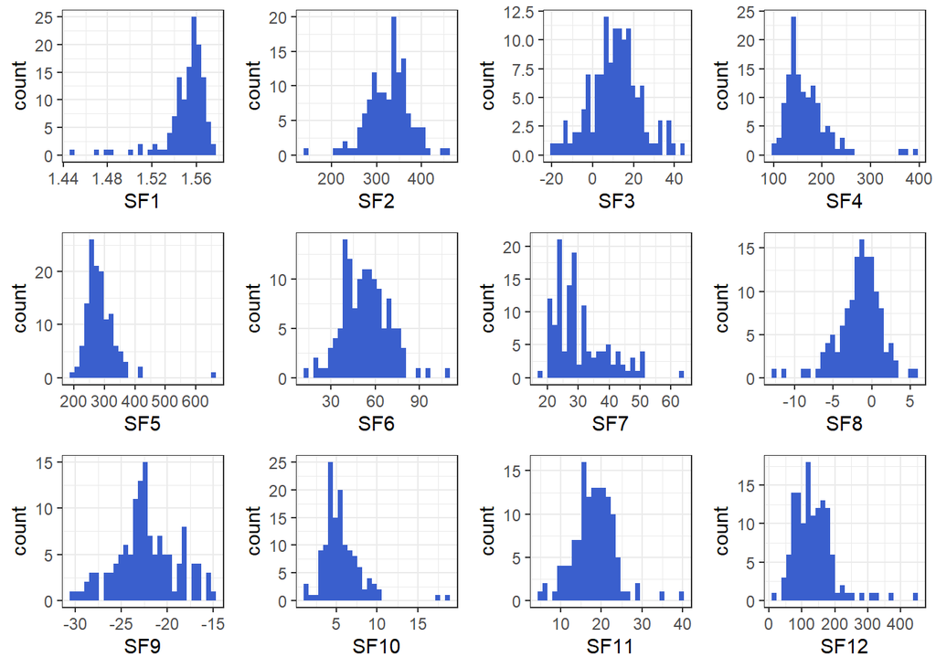

```r
hist.list1 = lapply(
 pred.voice[1:12],
  function(n)
    ggplot(data = df, aes_string(x = n)) +
    geom_histogram(fill="royalblue3") + theme_bw()
)
cowplot::plot_grid(plotlist = hist.list1)
```

#### 2. Speaking task of monologue

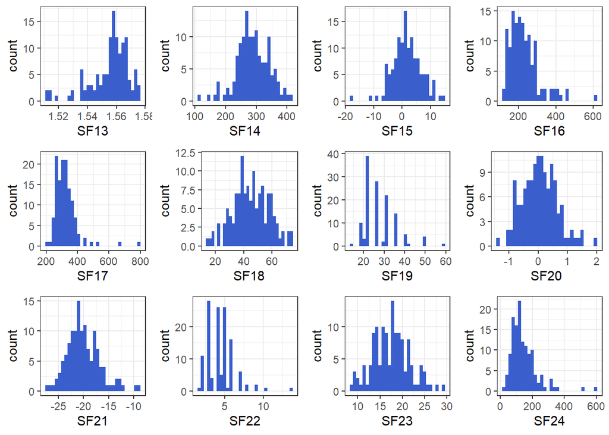

```r
hist.list2 = lapply(
  pred.voice[13:24],
  function(n)
    ggplot(data = df, aes_string(x = n)) +
    geom_histogram(fill="royalblue3") + theme_bw()
)
cowplot::plot_grid(plotlist = hist.list2)
```

Most speech features do not look normally distributed, maybe further variable transformations will be needed.

#### Testing normality of distributions: one-sample Kolmogorov-Smirnov test

```r
#Kolmogorov-Smirnov Tests - normality of distribution
kst.results = NULL
for (i in pred.voice) {
  kst = round(ks.test(df[,c(i)],"pnorm", mean(df[,c(i)]), sd(df[,c(i)]))$p.value,3)
  kst.results = rbind(kst.results, cbind(i, kst))
}
as.data.frame(kst.results)
```

```
##       i   kst
## 1   SF1 0.002
## 2   SF2 0.492
## 3   SF3 0.878
## 4   SF4 0.062
## 5   SF5 0.061
## 6   SF6 0.945
## 7   SF7 0.001
## 8   SF8 0.274
## 9   SF9 0.513
## 10 SF10 0.003
## 11 SF11 0.683
## 12 SF12 0.192
## 13 SF13 0.003
## 14 SF14 0.867
## 15 SF15 0.971
## 16 SF16 0.084
## 17 SF17 0.012
## 18 SF18 0.998
## 19 SF19 0.001
## 20 SF20 0.997
## 21 SF21 0.195
## 22 SF22 0.003
## 23 SF23 0.938
## 24 SF24 0.018
```

```r
table(as.numeric( as.character( as.data.frame(kst.results)$kst))>=0.05)
```

```
##
## FALSE  TRUE
##     8    16
```

16 features out of 24 are distributed normally.

#### Conclusion 1:

Only demographic and speech features are complete for all participants. Healthy controls do not have health history and clinical exam inforamation, and medication varialbes have zero variance (same values for all healthy controls). Thus, only demographics and speech features can be used for predictive modelling for ‘early’ detection of Parkinson’s Disease. Information on clinical exam (symptoms) can be further used for clustering patients and finding disease subgroups.

### 1.2. Bivariate analysis

#### 1.2.1. Correlation matrix of speech features

```r
library(corrplot)
cor2 <- rcorr(as.matrix(df[,pred.voice]), type = "spearman") # compute correlation matrix
df.cor <- cor2$r # Spearman rank correlation coefficients
p.mat <- cor2$P # p-values

library(RColorBrewer)
col <- colorRampPalette(brewer.pal(9, "RdBu"))
```

#### Correlation matrix (with coefficients and clustered)

White cells are non-significant correlations (P-value > .01)

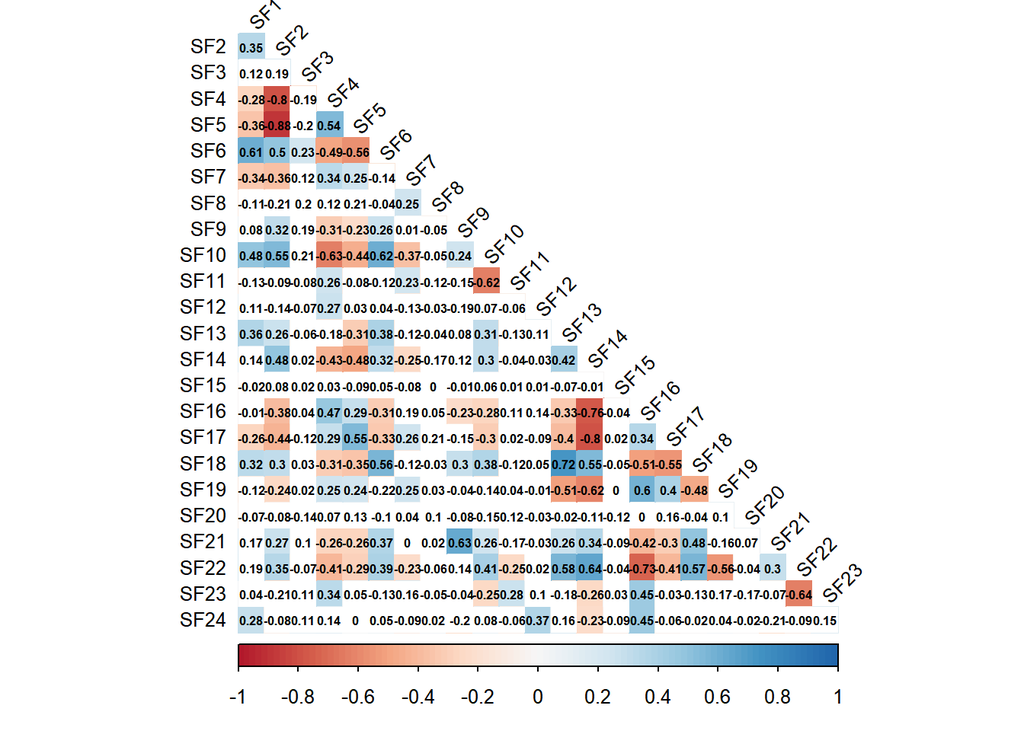

```r
corrplot(df.cor, method="color", col=col(100),
         type="lower",
         addCoef.col = "black",
         tl.col="black", tl.srt=45,
         p.mat = p.mat, sig.level = 0.01, insig = "blank",
         diag=F, number.cex=0.5, tl.cex = 0.8)
```

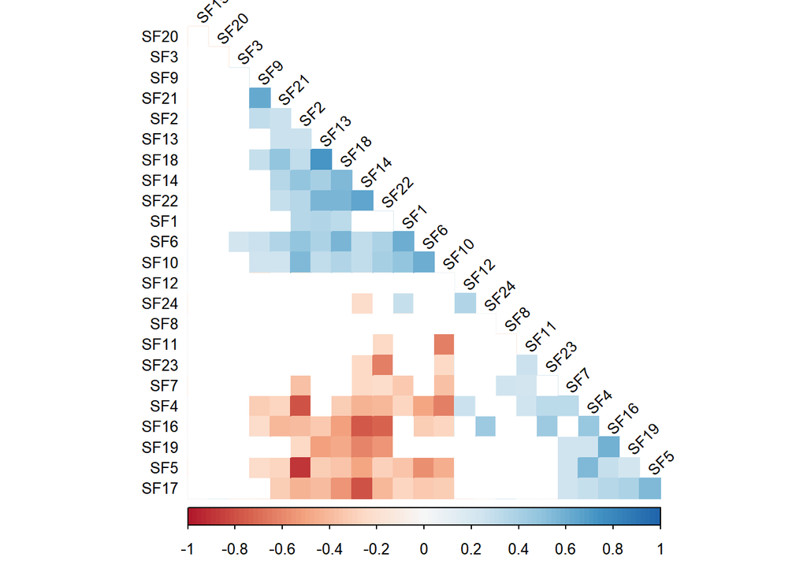

```r
corrplot(df.cor, method="color", col=col(100),
         type="lower", order="hclust", hclust.method = "centroid",
         tl.col="black", tl.srt=45,
         p.mat = p.mat, sig.level = 0.01, insig = "blank",
         diag=F, number.cex=0.5, tl.cex = 0.8 )
```

#### Corelation matrix heatmap with feature clustering

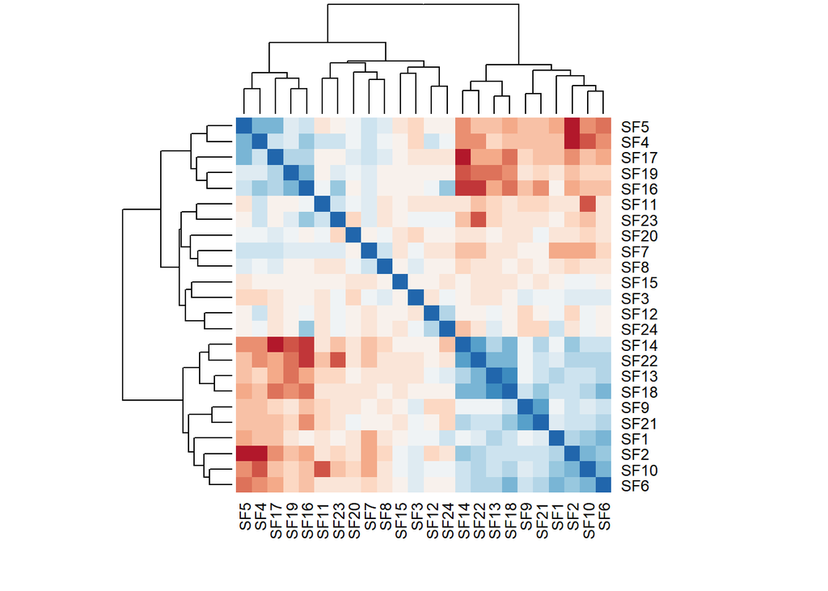

```r
heatmap(x = df.cor, col = col(20), symm = TRUE)
```

#### 1.2.2. Scatterplots of selected speech features

Closer look at correlated groups of features

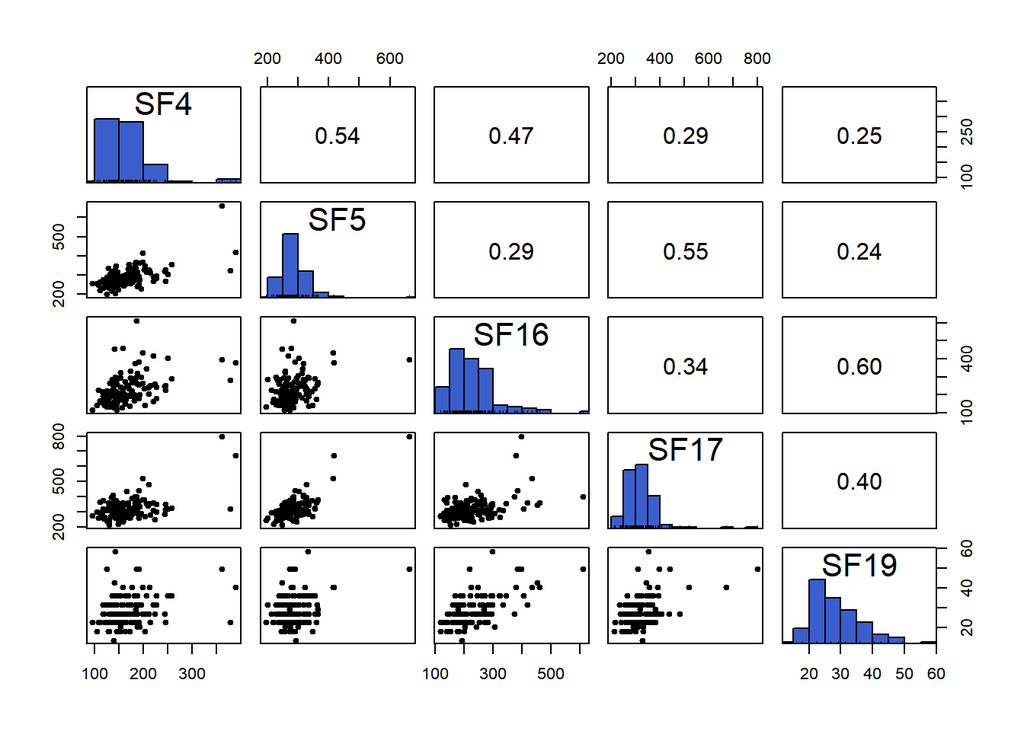

```r
pairs.panels(df[,c("SF4", "SF5", "SF16", "SF17", "SF19")],
             method = "spearman", # correlation method
             hist.col = "royalblue3",
             density = F,  # show density plots
             ellipses = F, # show correlation ellipses
             smooth = F, pch=19, cex.cor=0.6,cex=0.7)
```

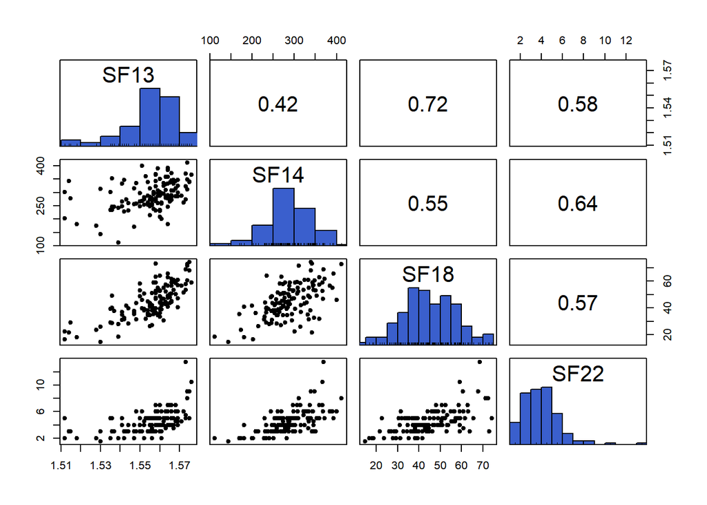

```r
pairs.panels(df[,c("SF13", "SF14", "SF18", "SF22")],
             method = "spearman", # correlation method
             hist.col = "royalblue3",
             density = F,  # show density plots
             ellipses = F, # show correlation ellipses
             smooth = F, pch=19, cex.cor=0.6,cex=0.8)
```

#### 1.2.3. PCA of speech features

Principal Components Analysis (PCA) allows deeper understanding of feature relations structure and revealing latent factors behind features. Thus, it can be used for reduction of dimensionality and feature selection in predictive modelling.

```r
library(factoextra)
set.seed(123)
pc <- prcomp(df[,pred.voice], scale.=T)
df.scores = pc$x # save individual data with component scores (can be used instead of features for prediction)
t(summary(pc)$importance) # importance of components (proportion of explained variance)
```

```
##      Standard deviation Proportion of Variance Cumulative Proportion
## PC1           2.6382083                0.29001               0.29001
## PC2           1.5357131                0.09827               0.38827
## PC3           1.3938414                0.08095               0.46922
## PC4           1.3443256                0.07530               0.54452
## PC5           1.2847968                0.06878               0.61330
## PC6           1.1488848                0.05500               0.66830
## PC7           1.0785052                0.04847               0.71677
## PC8           0.9891966                0.04077               0.75754
## PC9           0.9593137                0.03835               0.79588
## PC10          0.8514021                0.03020               0.82609
## PC11          0.8214711                0.02812               0.85420
## PC12          0.7991973                0.02661               0.88082
## PC13          0.7498443                0.02343               0.90424
## PC14          0.6453103                0.01735               0.92159
## PC15          0.5962698                0.01481               0.93641
## PC16          0.5793292                0.01398               0.95039
## PC17          0.5212788                0.01132               0.96172
## PC18          0.4755069                0.00942               0.97114
## PC19          0.4124412                0.00709               0.97822
## PC20          0.3910184                0.00637               0.98459
## PC21          0.3609658                0.00543               0.99002
## PC22          0.3390406                0.00479               0.99481
## PC23          0.3172980                0.00419               0.99901
## PC24          0.1542684                0.00099               1.00000
```

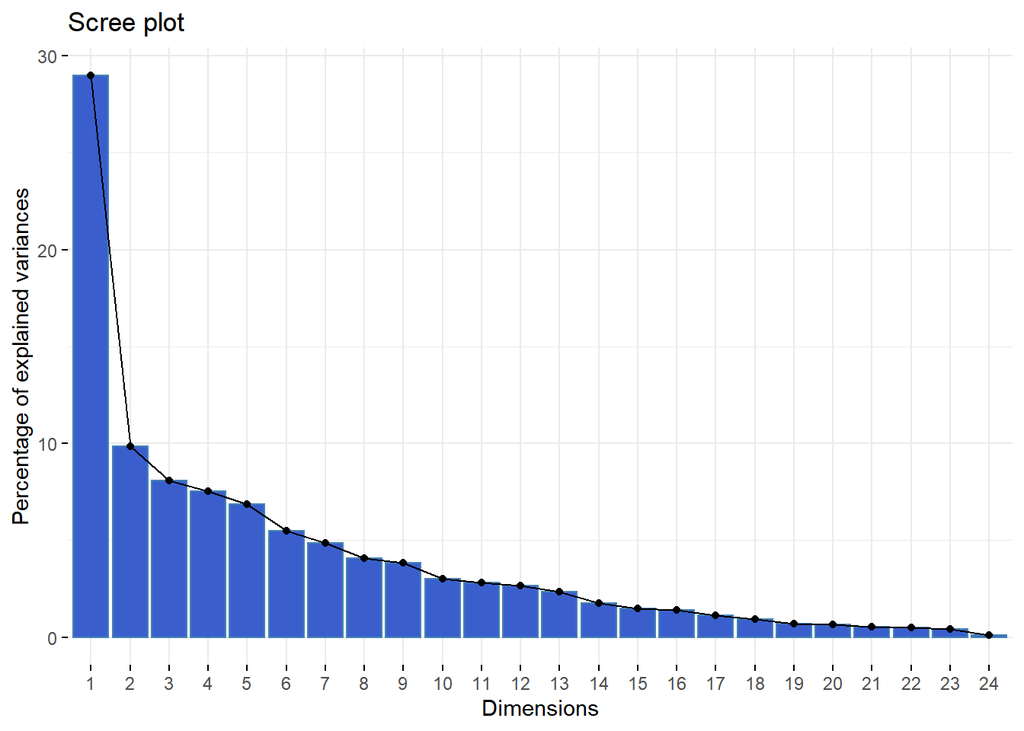

```r
fviz_screeplot(pc, ncp=24, barfill = "royalblue3") # importance of components
```

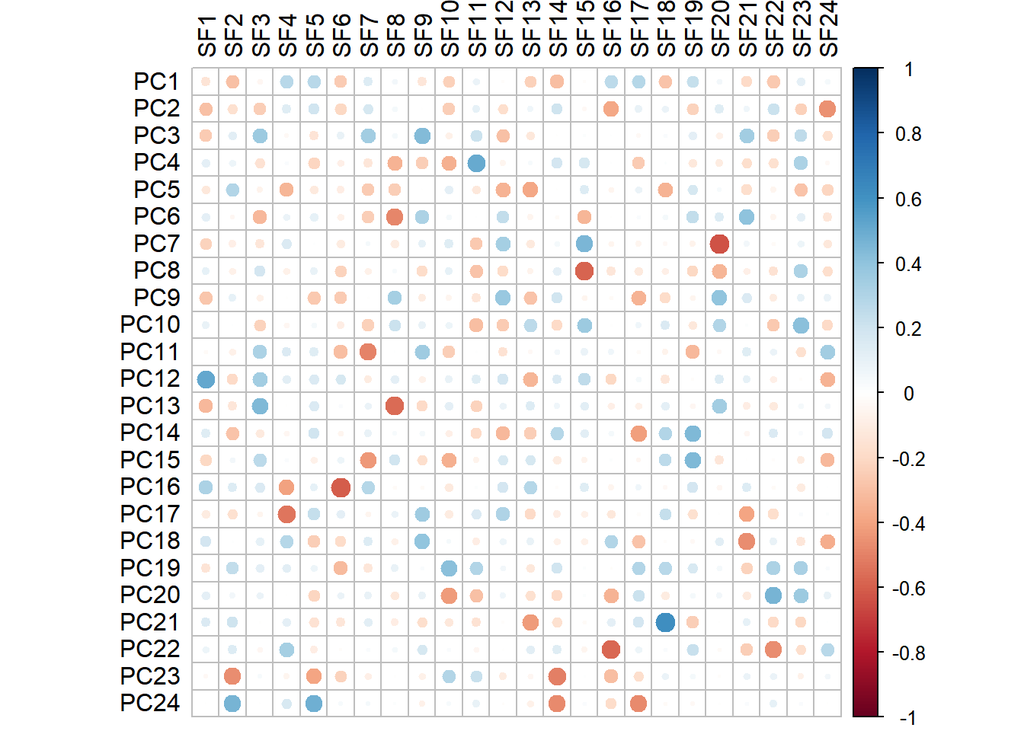

```r
corrplot(t(pc$rotation), tl.col="black") # plot feature loadings (contributions) in components
```

#### Feature contribution to 16 most important components

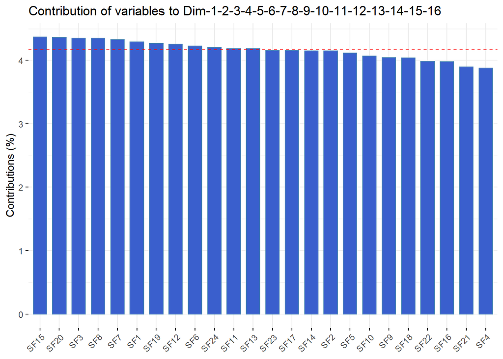

```r
fviz_contrib(pc, choice = "var", axes = 1:16, fill = "royalblue3")
```

1st component explains 29% of variance, wherein it is composed of multiple features with modest contribution, while other components explains <10% each. 16 components explain ~95% of total variability, and the contribution of functions to these components is fairly equal. Thus, there is not much benefit in reducing dimensionality, all features can contribute to models’ performance.

#### Conclusion 2:

All speech features potentially can contribute to models’ performance.

#### 1.2.4.Cluster analysis of participants using speech features

Rescale speech features within 0-1 range

```r
df.c = df
range01 <- function(x, ...){(x - min(x, ...)) / (max(x, ...) - min(x, ...))} # custom rescale function
df.c[,pred.voice] = sapply(df.c[,pred.voice],range01) # rescale values between 0 and 1
```

#### Cluster analysis with k-means

Find optimal number of clusters: Elbow method

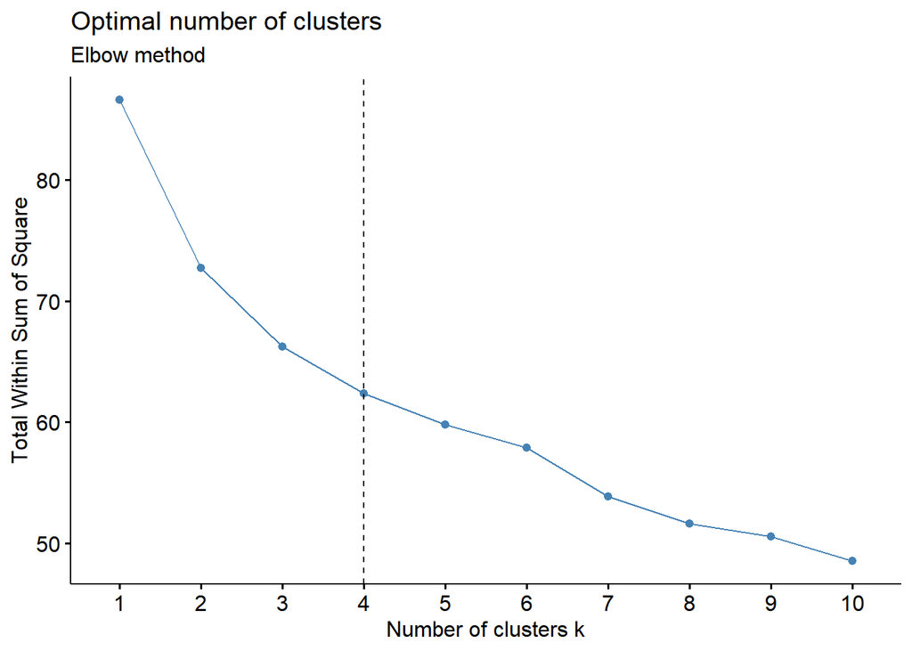

```r
fviz_nbclust(as.matrix(df.c[,pred.voice]), kmeans, method = "wss") +
  geom_vline(xintercept = 4, linetype = 2)+
  labs(subtitle = "Elbow method")
```

```r
set.seed(123)
clan <- kmeans(as.matrix(df.c[,pred.voice]), 4, nstart = 25) # k-mean clustering (k=4)
df.c$SF.cluster.4 = clan$cluster
table(df.c$SF.cluster.4)
```

```
##
##  1  2  3  4
## 26 21 47 36
```

Clusters are comparable by size.

#### Multidimensional Scaling

This method helps to triangulate clustering solution and visualize it along main latent dimensions

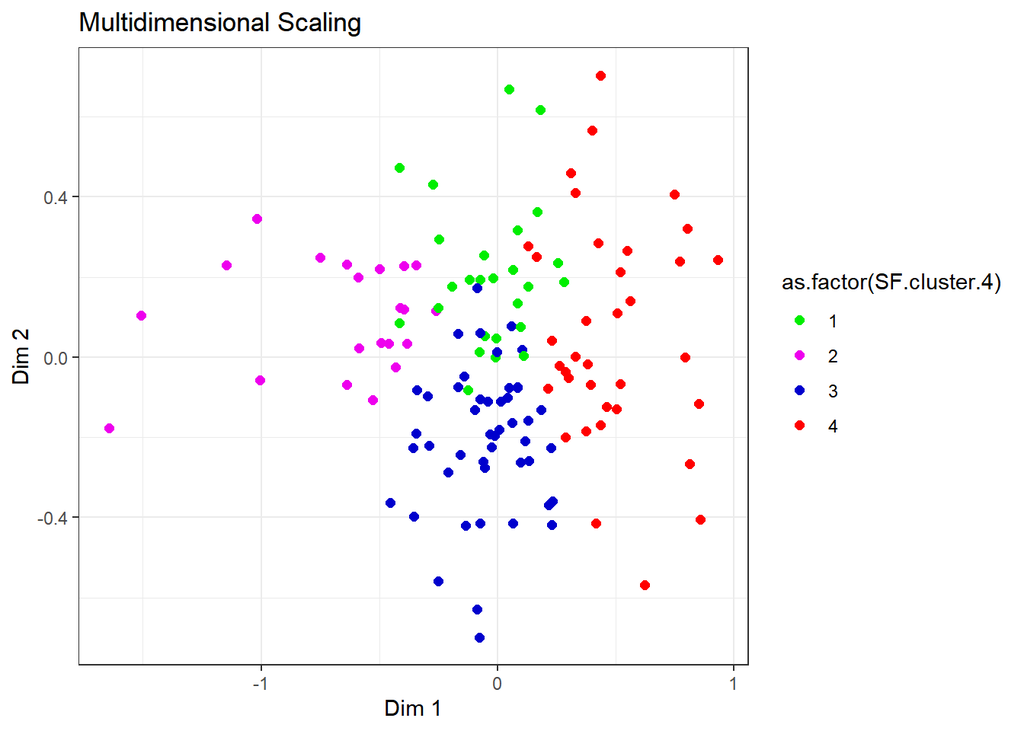

```r
d <- dist(df.c[,pred.voice], method = "euclidean") # euclidean distances between the rows
mds.sf <- cmdscale(d,eig=TRUE, k=2)

# plot solution
df.c$x <- mds.sf$points[,1]
df.c$y <- mds.sf$points[,2]

ggplot(data = df.c, aes(x = x, y = y,  color=as.factor(SF.cluster.4))) +
  geom_point(size=2) +
  theme_bw() + ylab("Dim 2") + xlab("Dim 1") + ggtitle("Multidimensional Scaling") +
  scale_color_manual(values=c("green2", "magenta2", "mediumblue", "red"))
```

Multidimensional scaling reduces 24 speech features into two-dimensional representation keeping maximum variability as possible. The scatterplot shows how participants clusters differ from each other along these dimensions. Groupings are pretty clear within this transformed speech feature space, hence this clustering probably captured some existing speech differences between participants.

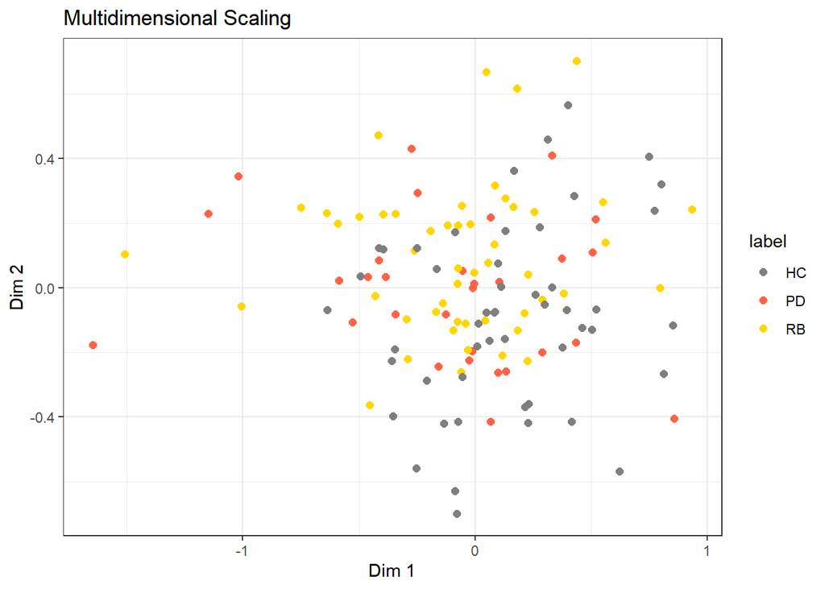

```r
ggplot(data = df.c, aes(x = x, y = y, color=label)) +
  geom_point(size=2) +
  theme_bw() + ylab("Dim 2") + xlab("Dim 1") + ggtitle("Multidimensional Scaling") +
  scale_color_manual(values=c("gray50", "tomato", "gold"))
```

This scatterplot shows how diagnostic groups differ from each other along these dimensions. PD and RBD patients tend to have higher Dim 2 and lower Dim 1, while healthy controls tend to have inverse parameters - lower Dim 2 and higher Dim 1. The top left corner of the plot mainly has PD and RBD patients (red and gold), while bottom right corner mainly has healthy controls (grey).

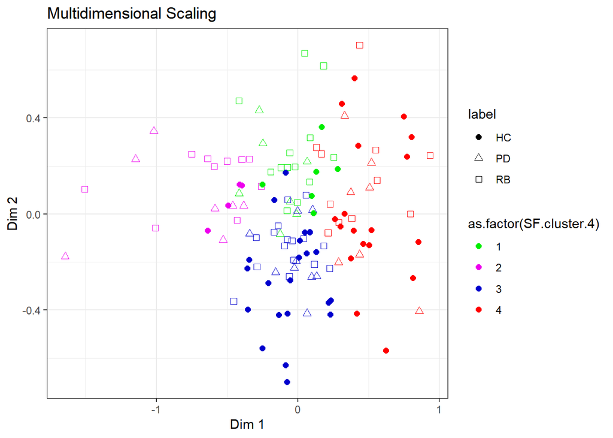

```r
ggplot(data = df.c, aes(x = x, y = y, shape=label, color=as.factor(SF.cluster.4))) +
  geom_point(size=2) +
  theme_bw() + ylab("Dim 2") + xlab("Dim 1") + ggtitle("Multidimensional Scaling") +
  scale_shape_manual(values=c(19,2,0)) +
  scale_color_manual(values=c("green2", "magenta2", "mediumblue", "red"))
```

Finally, this scatterplot shows both diagnostic groups and speech clusters of aprticipants. Healthy controls are mainly concentrated in clusters 3 and 4 (blue and red), while clusters 1 and 2 (green and purple) are mainly comprised of PD and RBD patients. The cross-tabulation below shows it.

```r
table(df.c$label, df.c$SF.cluster.4)
```

```
##
##       1  2  3  4
##   HC  6  4 22 18
##   PD  7  7  9  7
##   RB 13 10 16 11
```

## 2. Predictive modelling: ‘early’ detection of neurodegeneration (classification)

For detection of neurodegeneration (calssification) we will use:  
1. Three variants of outcomes (labels/classes):  
1.1. PD patients -vs- healthy controls  
1.2. PD and RBD patients -vs- healthy controls  
1.3. Multiclass prediction with 3 classes (PD, RBD and healthy controls)  
2. Four machine learning algorithms (naive Bayes, KNN, random forest, XGBoost). Features are handcrafted, and there is no need for deep learning.  
3. Two cross-validation methods (LOOCV, f-fold)

### 2.1. PD patients -vs- healthy controls

```r
library(caret)
library(MLeval)
library(doParallel)

df2 = df[df$label!="RB",] #subsample dataset (exclude RBD patients)

algs = c("nb", "knn", "rf", "xgbDART") # list of ML algorithms
set.seed(123)
cvIndex <- createFolds(factor(df2$label), 5, returnTrain = T)
k.fold <- trainControl(index = cvIndex,
                       method="cv", number = 5,
                       savePredictions = "final",
                       classProbs=T) # setup cross-validation method: k-fold
set.seed(123)
LOOCV <- trainControl(method="LOOCV",
                      savePredictions = "final",classProbs=T) # setup cross-validation method: leave-one-out-cross-validation

cla <- makePSOCKcluster(6) #parallel computing: allocate available CPU cores
registerDoParallel(cla)

perf.res = NULL
for (i in algs) { # model training loop with 5 ML methods and 2 cross-validation

set.seed(987)
mod1 <- train(label~., method=as.name(i), data = df2[,c("label", pred.voice)],
              trControl=k.fold ,na.action  = na.pass)
auroc1 <- evalm(mod1, positive = "PD", showplots=F)
CM1 = c(alg=i, CV="k-fold", round(confusionMatrix(mod1$pred$pred, mod1$pred$obs, positive = "PD")$overall[c(1:2,5)],2), round(confusionMatrix(mod1$pred$pred, mod1$pred$obs, positive = "PD")$byClass[c(1:4,7)],2), AUC = auroc1$stdres[[1]]$Score[13])

set.seed(987)
mod2 <- train(label~., method=as.name(i), data = df2[,c("label", pred.voice)],
              trControl=LOOCV ,na.action  = na.pass)
auroc2 <- evalm(mod2, positive = "PD", showplots=F)
CM2 = c(alg=i, CV="LOOCV", round(confusionMatrix(mod2$pred$pred, mod2$pred$obs, positive = "PD")$overall[c(1:2,5)],2), round(confusionMatrix(mod2$pred$pred, mod2$pred$obs, positive = "PD")$byClass[c(1:4,7)],2), AUC = auroc2$stdres[[1]]$Score[13])

res = rbind(CM1, CM2)
perf.res = rbind(perf.res, res)
  }
stopCluster(cla)
```

#### Performance evaluation results

[output not shown]

#### ROC curve of the best model

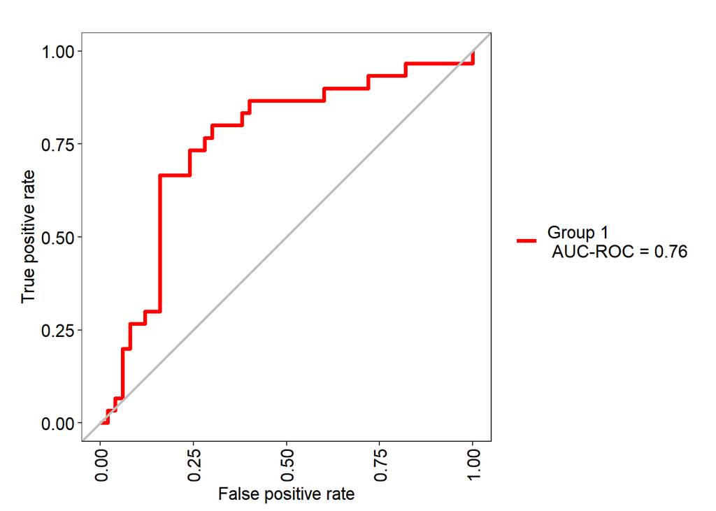

```r
auroc1$roc
```

#### Confusion matrix of the best model

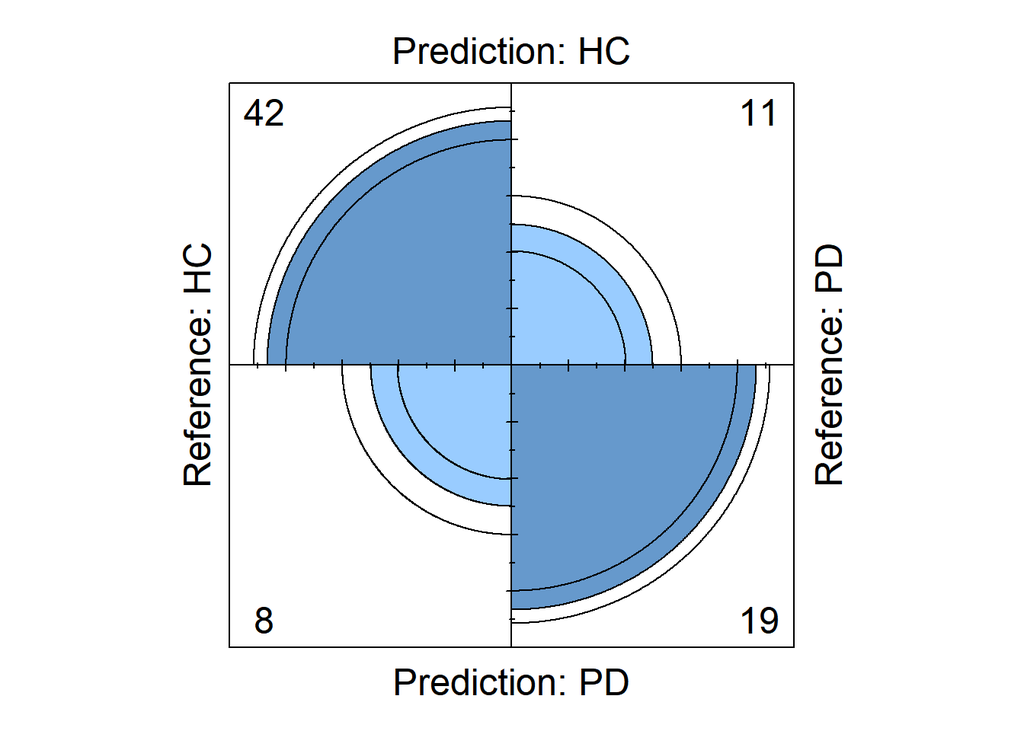

```r
fourfoldplot(confusionMatrix(mod1$pred$pred, mod1$pred$obs, positive = "PD")$table)
```

XGBoost performed better than others algorithms (76% accuracy and 0.76 AUC), so we will use only XGBoost for other tasks. LOOCV and k-fold cross-validation methods showed similar results, so k-fold cross-validation can be used further due to less computation.

Additionally, we will train predictive models using all available sample and evaluate their performance with cross-validation.

### 2.2. PD and RBD patients -vs- healthy controls

```r
df$neurodeg = ifelse(df$label == "HC", "control", "case") # create new class variable

set.seed(123)
cvIndex <- createFolds(factor(df$neurodeg), 10, returnTrain = T)
k.fold <- trainControl(index = cvIndex,method="cv", number = 10,
                       savePredictions = "final",classProbs=T) # setup cross-validation method: k-fold

cla <- makePSOCKcluster(6) #Parallel computing - set available number of CPU cores
registerDoParallel(cla)
set.seed(987)
mod3 <- train(neurodeg~., method="xgbDART", data = df[,c("neurodeg", rev(pred.voice))],
                  trControl=k.fold ,na.action  = na.pass)
stopCluster(cla)

confusionMatrix(mod3$pred$pred, mod3$pred$obs)
```

```
## Confusion Matrix and Statistics
##
##           Reference
## Prediction case control
##    case      73      22
##    control    7      28
##
##                Accuracy : 0.7769
##                  95% CI : (0.6956, 0.8452)
##     No Information Rate : 0.6154
##     P-Value [Acc > NIR] : 6.477e-05
##
##                   Kappa : 0.5007
##
##  Mcnemar's Test P-Value : 0.00933
##
##             Sensitivity : 0.9125
##             Specificity : 0.5600
##          Pos Pred Value : 0.7684
##          Neg Pred Value : 0.8000
##              Prevalence : 0.6154
##          Detection Rate : 0.5615
##    Detection Prevalence : 0.7308
##       Balanced Accuracy : 0.7363
##
##        'Positive' Class : case
##
```

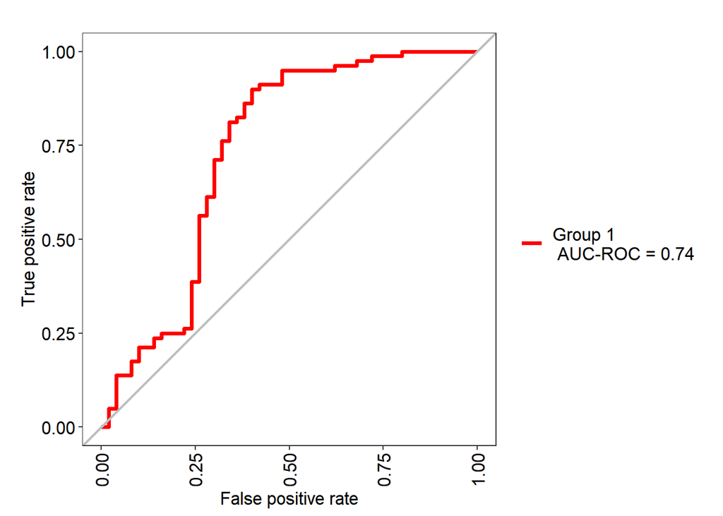

```r
auroc3 = evalm(mod3, positive = "case", plots = "r")
```

### 2.3. Multiclass prediction with 3 classes (PD, RBD and healthy controls)

Given the interesting results of cluster analysis based on speech features from section 1.2.4, we will use here the extended feature set including cluster memberships to train the model for multiclass calssification.

```r
set.seed(123)
cvIndex <- createFolds(factor(df.c$label), 5, returnTrain = T)
k.fold <- trainControl(index = cvIndex,method="cv", number = 5,
                       savePredictions = "final",
                       classProbs=T) # setup cross-validation method: k-fold

df.c$SF.cluster.4 = as.factor(df.c$SF.cluster.4)
cla <- makePSOCKcluster(6) #Parallel computing - set available number of CPU cores
registerDoParallel(cla)
set.seed(987)
mod4 <- train(label~., method="xgbDART", data = df.c[,c("label","SF.cluster.4", pred.voice)],
              trControl=k.fold, na.action = na.pass) # the model additionally includes cluster membership
stopCluster(cla)

confusionMatrix(mod4$pred$pred, mod4$pred$obs)
```

```
## Confusion Matrix and Statistics
##
##           Reference
## Prediction HC PD RB
##         HC 35  7  8
##         PD  3  9  7
##         RB 12 14 35
##
## Overall Statistics
##
##                Accuracy : 0.6077
##                  95% CI : (0.5182, 0.6921)
##     No Information Rate : 0.3846
##     P-Value [Acc > NIR] : 2.224e-07
##
##                   Kappa : 0.385
##
##  Mcnemar's Test P-Value : 0.1924
##
## Statistics by Class:
##
##                      Class: HC Class: PD Class: RB
## Sensitivity             0.7000   0.30000    0.7000
## Specificity             0.8125   0.90000    0.6750
## Pos Pred Value          0.7000   0.47368    0.5738
## Neg Pred Value          0.8125   0.81081    0.7826
## Prevalence              0.3846   0.23077    0.3846
## Detection Rate          0.2692   0.06923    0.2692
## Detection Prevalence    0.3846   0.14615    0.4692
## Balanced Accuracy       0.7562   0.60000    0.6875
```

Multiclass classification accuracy is 61%, no info rate is 38%, hence the model showed 23% of absolute accurcay growth and and 60% improvement compared to ‘random’ calssification [(61-38)/38].

### 2.4. Neurodegeneration symptoms’ severity prediction (numeric prediction)

For prediction of neurodegeneration severity (numeric prediction) we will use motor examination score - UPDRS III total.

```r
df3 = df[df$label != "HC",] # dataset with only PD and RBD patients

df3$UPDRS.score = as.numeric( as.character( df3$Overview..of..motor..examination...UPDRS..III..total.....)) #rename outcome and convert to numeric
set.seed(123)
k.fold <- trainControl(method="cv",
                       number = 10,
                       savePredictions = "final", returnResamp = "final") # setup cross-validation method: k-fold

cla <- makePSOCKcluster(6) #Parallel computing - set available number of CPU cores
registerDoParallel(cla)
set.seed(987)
mod5 <- train(UPDRS.score~., method="xgbDART", data = df3[,c("UPDRS.score", pred.voice)],
              trControl=k.fold, na.action = na.pass)
stopCluster(cla)
```

#### Correlation between predicted and observed scores

```r
cor.test(mod5$pred$pred, mod5$pred$obs)
```

```
##
##  Pearson's product-moment correlation
##
## data:  mod5$pred$pred and mod5$pred$obs
## t = 4.1952, df = 78, p-value = 7.153e-05
## alternative hypothesis: true correlation is not equal to 0
## 95 percent confidence interval:
##  0.2311359 0.5928871
## sample estimates:
##       cor
## 0.4290631
```

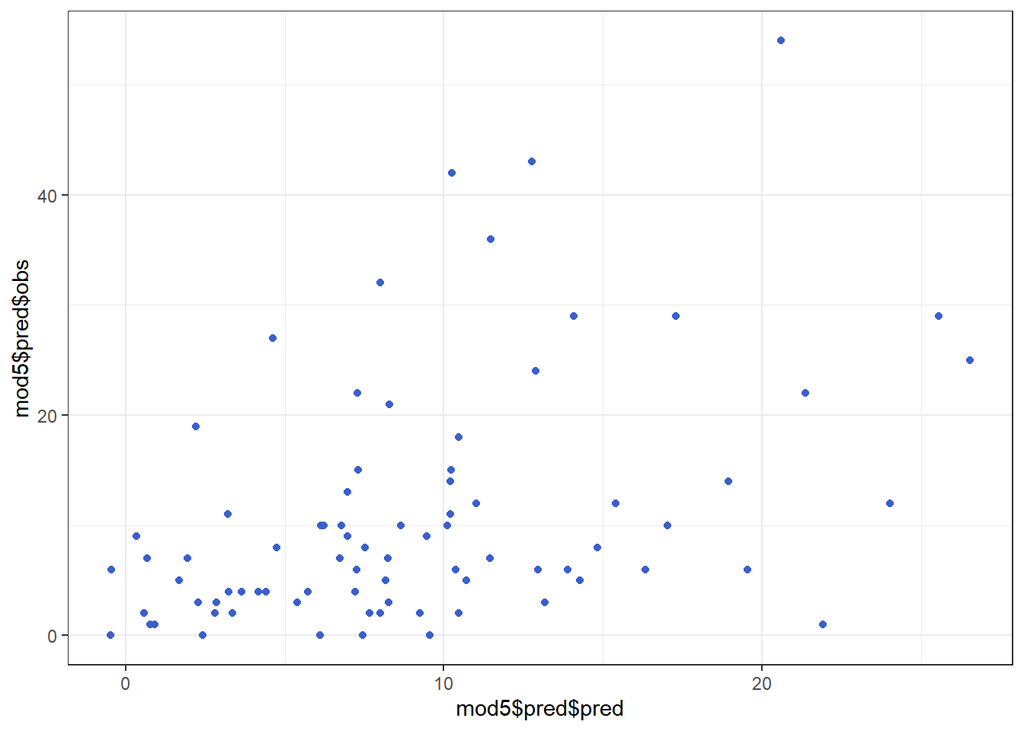

```r
qplot(mod5$pred$pred, mod5$pred$obs) + theme_bw() + geom_point(color = "royalblue3")
```

Correlation coefficient of 0.43 (P value <.001) shows that speech features have potential to assess severity of neurodegeneration symptoms even yet the variation in actual clinical exam scores is quite high.

## 3. Finding symptom patterns and predicting them by speech features

### 3.1. Finding symptom patterns with k-means cluster analysis

#### Preparing data

```r
df.c2 = df3
df.c2[,symptoms] <- sapply(df.c2[,symptoms], as.character)
df.c2[,symptoms] <- sapply(df.c2[,symptoms], as.numeric)
dichotomize <- function(x, ...){ifelse(x>0, 1, 0)} # custom function to dichotomize values, due to overall rare data and low actual variability
df.c2[,symptoms] = sapply(df.c2[,symptoms], dichotomize) # dichotomize
symptom.preval = colSums(as.matrix(df.c2[,symptoms]))/80 # compute prevalence of symptoms
symptoms3 = names(which(symptom.preval>0.4)) #selecting only prevalent symptoms (appeared in at least 40% of participants). Rare are symptoms highly likely appear only in more severy PD patients and adding them into k-means clustering will resilt in clustering by the overall severity score rather than by potential subtypes based on symptom patterns (co-occuring symptoms)
```

#### Find optimal number of clusters: Elbow method

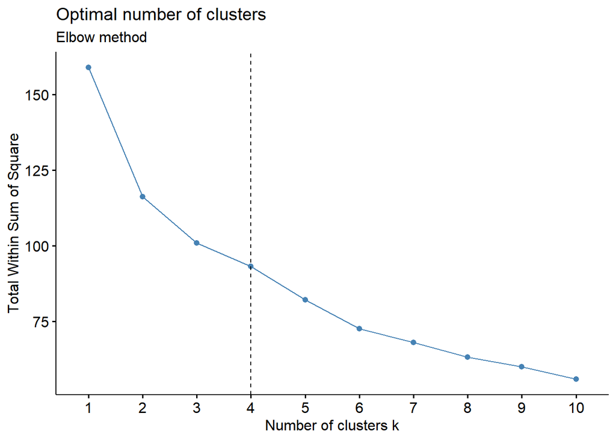

```r
fviz_nbclust(as.matrix(df.c2[,symptoms3]), kmeans, method = "wss") +
  geom_vline(xintercept = 4, linetype = 2)+
  labs(subtitle = "Elbow method")
```

#### K-means clustering (k = 4)

```r
set.seed(123)
clan <- kmeans(as.matrix(df.c2[,symptoms3]), 4, nstart = 25)
df.c2$cluster.4 = as.factor(clan$cluster)
levels(df.c2$cluster.4) = c("C1", "C2", "C3", "C4")
```

Checking how clusters relate to symptom severity

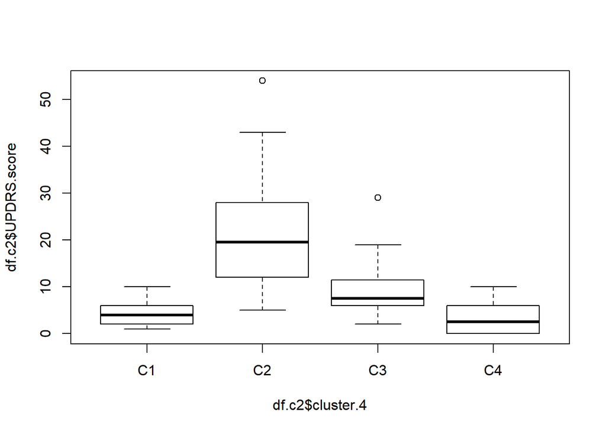

```r
boxplot(df.c2$UPDRS.score~df.c2$cluster.4)
```

Although symptom clusters overlap with overall severity, probably there is another meaningful latent factor/dimension.

#### Multidimensional Scaling

This method helps to triangulate clustering solution and visualize it along main latent dimensions

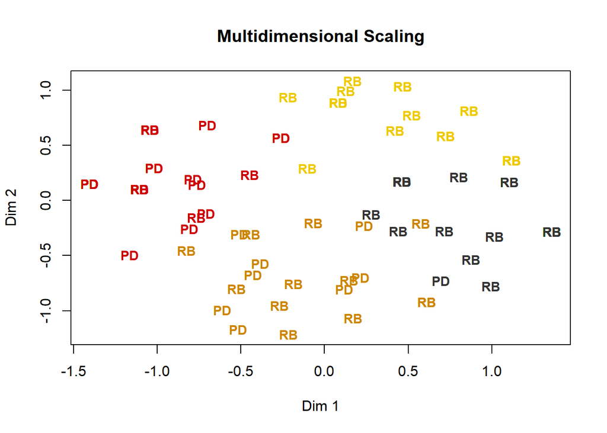

```r
d <- dist(df.c2[,symptoms3], method = "euclidean") # compute euclidean distances between participants
mds <- cmdscale(d,eig=TRUE, k=2)

x1 <- mds$points[,1] # MDS coordiantes
y1 <- mds$points[,2] # MDS coordiantes
df.c2$col.4 = ifelse(df.c2$cluster.4=="C2", "red3",
                     ifelse(df.c2$cluster.4=="C3", "orange3",
                            ifelse(df.c2$cluster.4=="C1", "gold2", "gray20")))
plot(x1, y1, xlab="Dim 1", ylab="Dim 2",
     main="Multidimensional Scaling", type="n")
text(x1, y1, labels = df.c2$label, cex=0.9, col = df.c2$col.4, font = 2)
```

Dim 1 corresponds to overall symptom severity (red - grey clusters along this axis), and points also vary along Dim 2 (gold - orange clusters along this axis) which captures some other factor than overall severity.

### 3.2. Predicting cluster of symptoms with speech features

Multiclass classification

```r
set.seed(123)
cvIndex <- createFolds(factor(df.c2$cluster.4), 4, returnTrain = T)
k.fold <- trainControl(index = cvIndex,method="cv",
                       number = 4,
                       savePredictions = "final",
                       classProbs=T) # setup cross-validation method: k-fold

cla <- makePSOCKcluster(6) #Parallel computing
registerDoParallel(cla)
set.seed(987)
modA <- train(cluster.4~., method="xgbDART", data = df.c2[,c("cluster.4", pred.voice)],
              trControl=k.fold, na.action = na.pass)
stopCluster(cla)

confusionMatrix(modA$pred$pred, modA$pred$obs)
```

```
## Confusion Matrix and Statistics
##
##           Reference
## Prediction C1 C2 C3 C4
##         C1  6  3  2  6
##         C2  5 13  5  5
##         C3  1  7 10  2
##         C4  6  1  3  5
##
## Overall Statistics
##
##                Accuracy : 0.425
##                  95% CI : (0.3151, 0.5406)
##     No Information Rate : 0.3
##     P-Value [Acc > NIR] : 0.01185
##
##                   Kappa : 0.2256
##
##  Mcnemar's Test P-Value : 0.67217
##
## Statistics by Class:
##
##                      Class: C1 Class: C2 Class: C3 Class: C4
## Sensitivity             0.3333    0.5417    0.5000    0.2778
## Specificity             0.8226    0.7321    0.8333    0.8387
## Pos Pred Value          0.3529    0.4643    0.5000    0.3333
## Neg Pred Value          0.8095    0.7885    0.8333    0.8000
## Prevalence              0.2250    0.3000    0.2500    0.2250
## Detection Rate          0.0750    0.1625    0.1250    0.0625
## Detection Prevalence    0.2125    0.3500    0.2500    0.1875
## Balanced Accuracy       0.5780    0.6369    0.6667    0.5582
```

Although, the overall accuracy is quite low, it is significantly above no info rate (43% vs 30%, p-value = 0.01). Hence the model can classify participants into different symptomatic groups and identify different symptom-based patterns of neurodegeneration.